# Tests für abhängige Stichproben

2021-09-20

**Kernfragen dieser Lehreinheit**

- Wie fertige ich Deskriptivstatistiken (Grafiken, Kennwerte) zur Veranschaulichung des Unterschieds zwischen zwei Gruppen an?

**abhängige Stichproben**

- Was sind Voraussetzungen des abhängigen *t*-Tests und wie prüfe ich sie?
- Wie führe ich einen abhängigen *t*-Test in R durch?
- Wie berechne ich den standardisierten Populationseffekt für abhängige Stichproben?
- Wie führe ich den Wilcoxon-Test für abhängige Stichproben in R durch?
- Wie berichte ich die statistischen Ergebnisse formal?

## Was erwartet Sie?

Nachdem wir uns die letzten Wochen mit dem Unterschied zwischen dem Mittelwert einer Stichprobe und dem Mittelwert der dazugehörigen Population, aus der die Stichprobe stammt, auseinandergesetzt haben, fokussieren wir uns nun auf Unterschiede zwischen zwei Gruppen (also zwei Stichproben).

## Aufbau der Sitzung

**abhängige Stichproben**

4. Fragestellung D: Sind jüngere Geschwister kooperativer als ältere? (*t-Test für abhängige Stichproben, standardisierter Populationseffekt*)
5. Fragestellung E: Geben Studierende in gleichem Maße an, dass es ihnen “nicht gut” geht bzw. sie “unzufrieden” sind, wie dass es ihnen “schlecht geht” bzw. sie sich “unwohl fühlen”? (*Wilcoxon-Test für abhängige Stichproben*)

## 4. Fragestellung D: Sind jüngere Geschwister kooperativer als ältere?

Datensatz aus: Eid, Gollwitzer & Schmitt: “Statistik und Forschungsmethoden” (4. Auflage, S. 370)

- AV: Kooperationsbereitschaft (stetige Variable mit Werten von 0 [nicht kooperativ] bis 1 [maximal kooperativ])
- Gruppen: das jeweils ältere Geschwisterteil (Gruppe “Älter”) vs. das jeweils jüngere Geschwisterteil (Gruppe “Jünger”)

```r
# Datensatz generieren
dataKooperation <- data.frame(Paar = 1:10,  Juenger = c(0.49,0.25,0.51,0.55,0.35,0.54,0.24,0.49,0.38,0.50), Aelter = c(0.4,0.25,0.31,0.44,0.25,0.33,0.26,0.38,0.23,0.35))
dataKooperation # überprüfen, ob alles geklappt hat
```

```
##    Paar Juenger Aelter
## 1     1    0.49   0.40
## 2     2    0.25   0.25
## 3     3    0.51   0.31
## 4     4    0.55   0.44
## 5     5    0.35   0.25
## 6     6    0.54   0.33
## 7     7    0.24   0.26
## 8     8    0.49   0.38
## 9     9    0.38   0.23
## 10   10    0.50   0.35
```

Ein Blick auf die Messwertpaare lässt bereits erkennen, dass die Stichproben (also die Messwerte in den beiden experimentellen Bedingungen) voneinander abhängig sind. Die Geschwisterpaare ähneln sich hinsichtlich ihrer kooperativen Verhaltenstendenzen.

Welche Ursachen diese Ähnlichkeiten haben, ist unwichtig. Entscheidend ist, dass es sich um Faktoren handelt, die sowohl einen Teil der Varianz in der ersten Gruppe als auch einen Teil der Varianz in der zweiten Gruppe erzeugen.

Relevant ist die Frage, ob die Differenz zwischen den beiden Mittelwerten (also zwischen jüngeren und älteren Geschwistern) statistisch bedeutsam ist.

### 4.1. Deskriptivstatistik

#### 4.1.1. grafisch

Mit Hilfe von Histogrammen

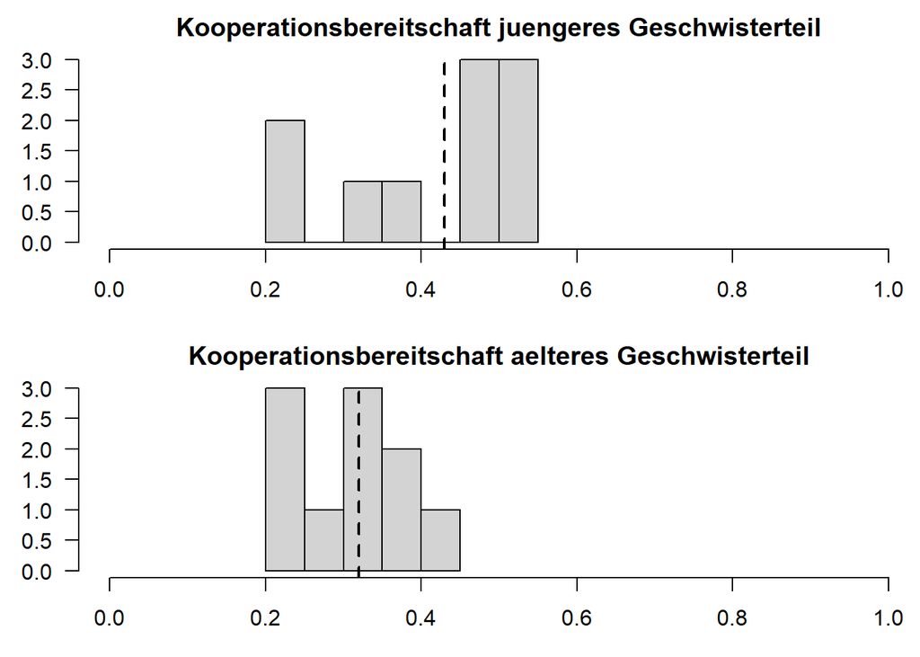

```r
# Je ein Histogramm pro Gruppe, untereinander dargestellt, vertikale Linie fuer den jeweiligen Mittelwert
par(mfrow=c(2,1), mar=c(3,3,2,0))
hist(dataKooperation[, "Juenger"],
     xlim=c(0,1),
     main="Kooperationsbereitschaft juengeres Geschwisterteil",
     xlab="",
     ylab="",
     las=1)
abline(v=mean(dataKooperation[, "Juenger"]),
       lty=2,
       lwd=2)

hist(dataKooperation[, "Aelter"],
     xlim=c(0,1),
     main="Kooperationsbereitschaft aelteres Geschwisterteil",
     xlab="",
     ylab="",
     las=1)
abline(v=mean(dataKooperation[, "Aelter"]),
       lty=2,
       lwd=2)
```

```r
par(mfrow=c(1,1)) #Zuruecksetzen des Plotfensters
```

#### 4.1.2. statistisch

```r
summary(dataKooperation[, "Juenger"])
```

```
##    Min. 1st Qu.  Median    Mean 3rd Qu.    Max.
##  0.2400  0.3575  0.4900  0.4300  0.5075  0.5500
```

```r
summary(dataKooperation[, "Aelter"])
```

```
##    Min. 1st Qu.  Median    Mean 3rd Qu.    Max.
##  0.2300  0.2525  0.3200  0.3200  0.3725  0.4400
```

```r
#alternativ
library(psych)
describe(dataKooperation[, "Juenger"])
```

```
##    vars  n mean   sd median trimmed  mad  min  max range  skew kurtosis   se
## X1    1 10 0.43 0.12   0.49    0.44 0.08 0.24 0.55  0.31 -0.57    -1.46 0.04
```

```r
describe(dataKooperation[, "Aelter"])
```

```
##    vars  n mean   sd median trimmed mad  min  max range skew kurtosis   se
## X1    1 10 0.32 0.07   0.32    0.32 0.1 0.23 0.44  0.21 0.23    -1.57 0.02
```

Achtung: Bei den hier berichteten SD handelt es sich (wie immer in R) den Populationsschätzer.

### 4.2. Voraussetzungsprüfung

**Voraussetzungen für die Durchführung des *t*-Tests:**

1. Die abhängige Variable ist intervallskaliert $\rightarrow$ ok
2. Die Messwerte innerhalb der Paare dürfen sich gegenseitig beeinflussen/voneinander abhängig sein; keine Abhängigkeiten zwischen den Messwertpaaren $\rightarrow$ ok
3. Die Differenzvariable *d* muss in der Population normalverteilt sein $\rightarrow$ ab *n* => 30 meist gegeben (s. zentraler Grenzwertsatz), ggf. grafische Prüfung oder Hintergrundwissen

**zu 3. Normalverteilung von *d***

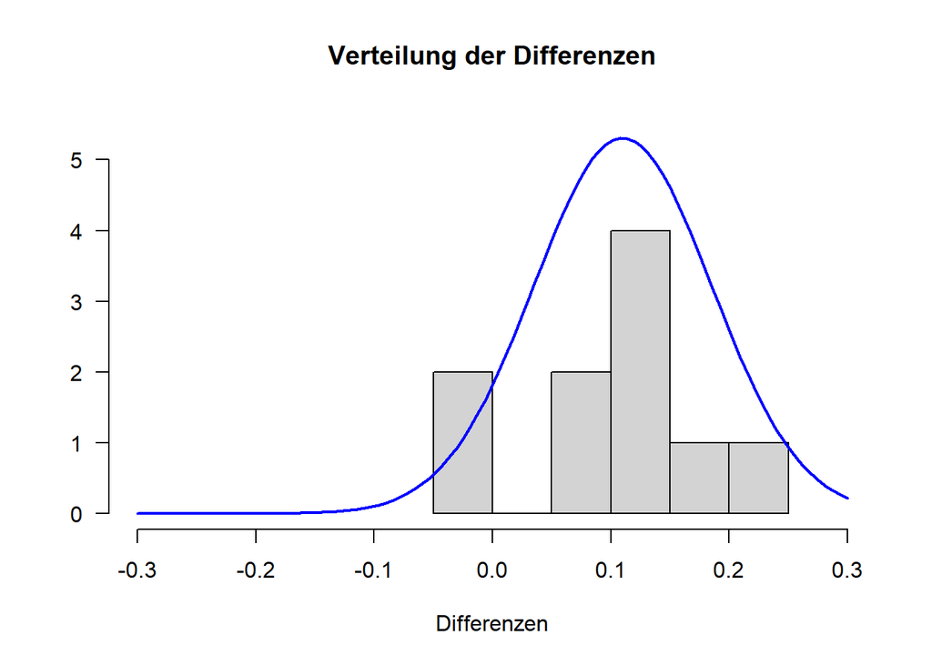

```r
difference <- dataKooperation[, "Juenger"]-dataKooperation[, "Aelter"]
hist(difference,
     xlim=c(-.3,.3),
     ylim = c(0,5.5),
     main="Verteilung der Differenzen",
     xlab="Differenzen",
     ylab="",
     las=1)
curve(dnorm(x, mean=mean(difference), sd=sd(difference)),
      col="blue",
      lwd=2,
      add=T)
```

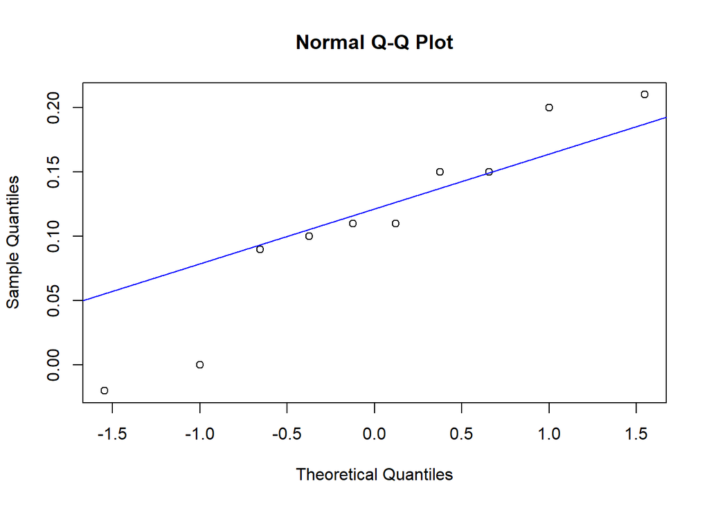

```r
qqnorm(difference)
qqline(difference, col="blue")
```

$\Rightarrow$ Differenzen sehen nicht normalverteilt aus!

Allerdings s. Info aus Eid, Gollwitzer & Schmitt: “Zur Messung zur Kooperationsbereitschaft verwendet [der Forscher] ein standardisiertes Instrument, das Messwerte auf Intervallskalenniveau liefert und in der Population normalverteilt ist.”

$\Rightarrow$ Es wird also Normalverteilung angenommen, somit sind alle drei Voraussetzungen für die Durchführung des *t*-Tests für abhängige Stichproben erfüllt.

### 4.3. Inferenzstatistik: *t*-Test für abhängige Stichproben

Zur Erinnerung:

> Fragestellung D: “Sind jüngere Geschwister kooperativer als Ältere?”

**Hypothesen:**

- Art des Effekts: Unterschiedshypothese
- Richtung des Effekts: Gerichtet - positiver Effekt
- Grösse des Effekts: Unspezifisch

Hyothesenpaar (inhaltlich):

- H0: Jüngere Geschwister sind genau so oder weniger kooperativ wie ältere Geschwister.
- H1: Jüngere Geschwister sind kooperativer als ältere Geschwister.

Hypothesenpaar (statistisch):

- H0: $\mu_{juenger} \le \mu_{aelter}$ bzw. $\mu_{d} \le 0$
- H1: $\mu_{juenger} > \mu_{aelter}$ bzw. $\mu_{d} > 0$

**Signifikanzniveau**

Das Signifikanzniveau muss vor der Untersuchung festgelegt werden. Es soll hier 5% betragen. $\rightarrow$ $\alpha=.05$

**Durchfürhung des abhängigen *t*-Tests in R:**

```r
t.test(x = dataKooperation[, "Juenger"], y  = dataKooperation[, "Aelter"], # die beiden abhaengigen Gruppen
       paired = T,                                                         # Stichproben sind abhaengig
       alternative = "greater",                                            # gerichtete Hypothese
       conf.level = .95)                                                   # alpha = .05
```

```
##
##  Paired t-test
##
## data:  dataKooperation[, "Juenger"] and dataKooperation[, "Aelter"]
## t = 4.63, df = 9, p-value = 0.0006183
## alternative hypothesis: true difference in means is greater than 0
## 95 percent confidence interval:
##  0.06644883        Inf
## sample estimates:
## mean of the differences
##                    0.11
```

*df* bei *t*-test mit abhängigen Stichproben: $n - 1$ (wobei $n$ die Anzahl der Paare darstellt)  
$\rightarrow$ *t*(9) = 4.63, *p* < .001 $\rightarrow$ signifikant, H0 wird verworfen, H1 wird angenommen.

### 4.4. Schätzung des standardisierten Populationseffekts

Formel:
$$d_2'' = \frac{\bar{d}} {sd_{\hat{d}}}$$

wobei

- $\bar{d}$: Mittelwert der Differenz aller Wertepaare
- $sd_{\hat{d}}$: geschätzte SD der Differenzen

```r
mean_d <- mean(difference)
sd.d.est <- sd(difference)
d_Kooperation <- mean_d/sd.d.est
```

Konventionen nach Cohen (1988) für *t*-Test für abhängige Stichproben (Achtung: Werte unterscheiden sich zw. abhängigem und unabhängigem t-Test):

| *d’’* | Interpretation |
| --- | --- |
| ~ .14 | kleiner Effekt |
| ~ .35 | mittlerer Effekt |
| ~ .57 | grosser Effekt |

$\Rightarrow$ der standardisierte Populationseffekt beträgt $d_2''$ = 1.46 und ist laut Konventionen gross.

### 4.5. Ergebnisinterpretation

Es wurde an Geschwisterpaaren untersucht, ob jüngere Geschwister kooperativer sind als ältere Geschwister. Zunächst findet sich deskriptiv ein Unterschied: Jüngere Geschwister weisen einen durchschnittlichen Wert von 0.43 (*SD* = 0.12) auf, während die älteren Geschwister einen Wert von 0.32 (*SD* = 0.07) aufweisen. Zur Beantwortung der Fragestellung wurde ein gerichteter *t*-Test für abhängige Stichproben durchgeführt. Der Gruppenunterschied ist signifikant (*t*(9) = 4.63, *p* < .001), somit wird die Nullhypothese verworfen. Jüngere Geschwister sind kooperativer als ihre älteren Geschwister.Dieser Unterschied ist nach dem standardisierte Populationseffekt von $d_2''$ = 1.46 gross.

## 5. Fragestellung E: Geben Studierende in gleichem Maße an, dass es ihnen “nicht gut” geht bzw. sie “unzufrieden” sind, wie dass es ihnen “schlecht geht” bzw. sie sich “unwohl fühlen”?

Wir prüfen also Unterschiede in der Antworttendenz: Fällt es leichter, bei positiv formulieren Items nicht zuzustimmen als bei negativ formulierten Items zuzustimmen (und umgekehrt)?

```r
setwd("...")
load("fb20.rda")
```

**Vorbereitungen**

```r
# Item mdbf4: Wie schlecht fuehlen Sie sich? Hohe Werte = schlecht
# Item mdbf8: Wie gut fuehlen Sie sich? Hohe Werte = gut
fb20$mdbf8_r <- -1 * (fb20$mdbf8 - 6) # Item mdbf8 umpolen
# Item mdbf8_r: Umgepolt -> Wie "nicht gut" fuehlen Sie sich? Hohe Werte = schlecht

# Item mdbf11: Wie unwohl fuehlen Sie sich? Hohe Werte = unwohl
# Item mdbf1: Wie zufrieden fuehlen Sie sich? Hohe Werte = zufrieden
fb20$mdbf1_r <- -1 * (fb20$mdbf1 - 6) # Item mdbf1 umpolen
# Item mdbf1_r: Umgepolt -> Wie "unzufrieden" fuehlen Sie sich? Hohe Werte = unzufrieden

#umgepolte positive Skalen mitteln ueber beide Items
fb20$schlecht_r <- rowMeans(fb20[, c('mdbf1_r', 'mdbf8_r')])
#negative Skalen mitteln ueber beide Items
fb20$schlecht <- rowMeans(fb20[, c('mdbf4', 'mdbf11')])
```

Unterscheiden sich die Gruppen im Mittel nicht, geben die Studierenden auf den Skalen im gleichen Maße an, wie es ihnen geht (unabhängig von der Polung der Items).

### 5.1. Deskriptivstatistik

#### 5.1.1. grafisch

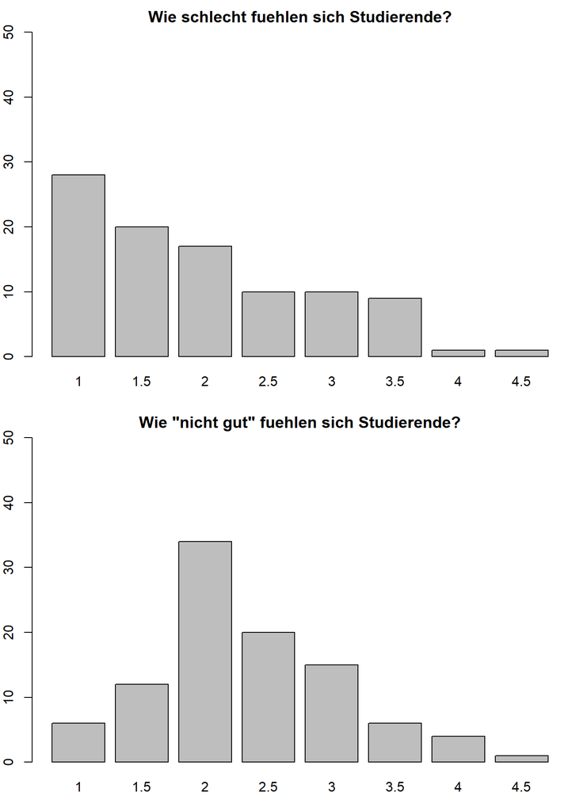

```r
par(mfrow=c(2,1), mar=c(3,2,2,0))
barplot(table(fb20$schlecht),
        ylim = c(0,50),
        ylab = 'Anzahl',
        main = "Wie schlecht fuehlen sich Studierende?")
barplot(table(fb20$schlecht_r),
        ylim = c(0,50),
        ylab = 'Anzahl',
        main = paste('Wie "',"nicht gut", '" fuehlen sich Studierende?',
                     sep=""))
```

```r
par(mfrow=c(1,1))
```

#### 5.1.2. statistisch

```r
summary(fb20$schlecht)
```

```
##    Min. 1st Qu.  Median    Mean 3rd Qu.    Max.    NA's
##   1.000   1.000   1.750   1.948   2.500   4.500       2
```

```r
summary(fb20$schlecht_r)
```

```
##    Min. 1st Qu.  Median    Mean 3rd Qu.    Max.
##   1.000   2.000   2.000   2.332   3.000   4.500
```

```r
prop.table(table(fb20$schlecht))
```

```
##
##          1        1.5          2        2.5          3        3.5          4
## 0.29166667 0.20833333 0.17708333 0.10416667 0.10416667 0.09375000 0.01041667
##        4.5
## 0.01041667
```

```r
prop.table(table(fb20$schlecht_r))
```

```
##
##          1        1.5          2        2.5          3        3.5          4
## 0.06122449 0.12244898 0.34693878 0.20408163 0.15306122 0.06122449 0.04081633
##        4.5
## 0.01020408
```

### 5.2. Inferenzstatistik: Wilcoxon-Test für abhängige Stichproben

Grund: Annahme von Intervallskalenniveau der AV ist verletzt

Zur Erinnerung:

> Fragestellung E: Geben Studierende in gleichem Maße an, dass es ihnen “nicht gut” geht bzw. sie “unzufrieden” sind, wie dass es ihnen schlecht geht bzw. sie sich unwohl fühlen?

$\Rightarrow$ Fragestellung ist ungerichtet, erfordert also auch ungerichtete Hypothese.

**Hypothesen**

Hypothesenpaar (inhaltlich):

- H0: Studierende geben im gleichen Ausmaß ihr Befinden an (egal, wie rum Items formuliert sind).
- H1: Studenten geben nicht im gleichen Ausmaß ihr Befinden an (es ist nicht egal, wie rum Items formuliert sind).

Hypothesenpaar (statitisch):

- H0: $\mu_{"nicht gut"/"unzufrieden"} = \mu_{schlecht/unwohl}$ bzw. $\mu_{d} = 0$
- H1: $\mu_{"nicht gut"/"unzufrieden"} \ne \mu_{schlecht/unwohl}$ bzw. $\mu_{d} \ne 0$

**Signifikanzniveau**

Das Signifikanzniveau muss vor der Untersuchung festgelegt werden. Es soll hier 5% betragen. $\rightarrow$ $\alpha=.05$

**Durchfuehrung des Wilcoxon-Tests für abhängige Stichproben in R:**

```r
wilcox.test(x = fb20$schlecht_r, y = fb20$schlecht,
            paired = T,                       # Stichproben sind abhaengig
            alternative = "two.sided",        # zweiseitige Testung
            conf.level = .95)                 # alpha = .05
```

```
##
##  Wilcoxon signed rank test with continuity correction
##
## data:  fb20$schlecht_r and fb20$schlecht
## V = 1935, p-value = 1.877e-06
## alternative hypothesis: true location shift is not equal to 0
```

*V* = 1935, *p* < .001 $\rightarrow$ H0 wird verworfen, H1 wird angenommen

### 5.3. Ergebnisinterpretation

Es wurde untersucht, ob Studierende in gleichem Maße angeben, dass es ihnen “nicht gut” geht bzw. sie “unzufrieden” sind, wie dass es ihnen schlecht geht bzw. sie sich unwohl fühlen. Zur Beantwortung der Fragestellung wurde ein zweiseitiger Wilcoxon-Test für abhängige Stichproben durchgeführt. Der Unterschied wurde bei einem Signifikanzniveau von alpha = .05 signifikant (*V* = 1935, *p* < .001). Somit wird die Nullhypothese verworfen und die Alternativhypothese angenommen: Studierende machen also unterschiedliche Angaben zu ihrer Stimmung je nachdem, ob die Items positiv oder negativ formuliert sind.